# STAT 402 Case Study Analysis

Jonathan Fitz and Dong Liang

April 13, 2018

### Introduction

We were asked to answer the following questions about a data set provided by the Statistical Society of Canada:

- Which risk factors are associated with hypertension? Do these factors vary between men and women, and across age groups?

We interpreted this question as follows:

- Which risk factors have an effect on average hypertension after all other risk factors have been taken into account? Does the effect of these risk factors vary by gender or age?

```r
knitr::opts_chunk$set(fig.align = "center", out.width = "70%")  # Centers and sets width of graphs in output document
library(tidyverse)  # a set of packages including ggplot2
library(caret)  # used for knn and cross-validation
library(car)  # calculates VIF to check for multicollinearity
library(ResourceSelection)  # Hosmer-Lemeshow goodness-of-fit test
# Bring the chms_2018 dataset into R, and remove the weights as they are not used in this analysis
study_data = read.csv("chms_2018.csv")
study_data = select(study_data, -starts_with("BS"), -starts_with("WGT"))
# Make SMK_12 a factor
study_data$SMK_12 = as.factor(study_data$SMK_12)
# Choose seeds so that results from imputing censored data is fixed.
# These numbers were drawn from a Uniform distribution with boundaries (1, 10^9). This will not be truly random, but will suffice for our purposes
seed1 = 336741157
seed2 = 874515716
```

### Cleaning the Data

There were two explanatory variables (LAB_BCD and LAB_BHG) that contained observations too small to be detected. In other words, these observations were below the limit of detection (LOD) of their respective variable; these kinds of observations will be referred to in this report as censored data. This was not a minor issue either; while roughly only 2% of LAB_BCD values were below their LOD, a more significant 20% of LAB_BHG values were below their LOD.

The simplest solution to this problem would have been to remove all censored data from the data set. While this is a very simple method to implement, it has the drawback of reducing the sample size and also introducting bias into the final results. In our case for example, more than 20% of the observations would have been dropped, and we considered this to be unacceptable.

Thus, we decided to estimate the censored data. A common approach is to replace all the censored data of a particular variable with a single value such as LOD/2 or LOD/sqrt(2). However, this approach has little statistical justification, and so was avoided: see Lafleur et al. (2011).

Estimating censored data turns out to be a tricky problem however, and while more complex solutions were considered, ultimately a simple method was settled on: the censored data for a variable would be replaced by randomly drawing values from the interval (0, LOD). While this approach probably cannot be strongly justified from a statistical perspective, it is simple, which is a legitimate advantage from a practical perspective. Additionally, we hoped that drawing from a pool of values (instead of using a single value like LOD/2) would better reflect the variance that the true values undoubtedly possess.

This process is implemented below.

```r
# The values for LAB_BCD and LAB_BHG have been set to 999.5 when the patients recorded values are too low to
# be measured (ie. they are below the LOD). First understand how common this is
BCD_LOD = sum(study_data$LAB_BCD == 999.5, na.rm = TRUE)
BCD_LOD  # 999.5 appears 54 times in LAB_BCD
```

```
[1] 54
```

```r
BHG_LOD = sum(study_data$LAB_BHG == 999.5, na.rm = TRUE)
BHG_LOD  # 999.5 appears 599 times in LAB_BHG
```

```
[1] 599
```

```r
# The values below the LOD are replaced with randomly drawn elements from the interval (0, LOD); this is called jittering
set.seed(seed1)
study_data$LAB_BCD[study_data$LAB_BCD == 999.5 & !is.na(study_data$LAB_BCD)] = runif(BCD_LOD, 0, 0.71)
set.seed(seed2)
study_data$LAB_BHG[study_data$LAB_BHG == 999.5 & !is.na(study_data$LAB_BHG)] = runif(BHG_LOD, 0, 2.1)
# Confirm that all values below the LOD have been replaced.
sum(study_data$LAB_BCD == 999.5, na.rm = TRUE)  # 999.5 appears 0 times in LAB_BCD
```

```
[1] 0
```

```r
sum(study_data$LAB_BHG == 999.5, na.rm = TRUE)  # 999.5 appears 0 times in LAB_BHG
```

```
[1] 0
```

We then turned our attention to the missing values in the data set. Approximately 6% of the observations contained at least one regressor with a missing value, and these missing values were spread across four variables.

To solve this problem, we considered reusing the method outlined above; that is, estimating the missing values by replacing them with a single value (such as the sample mean of the variable they came from), or by replacing them with randomly drawn values from the sampling distribution of their variable.

To improve upon these methods however, we created four different models, each of them having as a response variable one of the variables with missing data. In order to simplify the problem, the non-parametric K-Nearest-Neighbors (KNN) method was used. After all, a parametric approach would have required the time-consuming process of making and checking model assumptions for each of the four models. Additionally, KNN was chosen due to its popularity and ease of use.

These four models were trained on the subset of sample observations that contained no missing values. Specifically, 5-fold cross-validation was used to estimate the value of K (the number of neighbors) that would minimize the estimated test error; 5 folds were chosen to balance the bias and variance of the predictors: see Breiman and Spector (1992).

```r
# Use K-Nearest-Neighbors (KNN) to estimate missing values
# Check how many missing values there are in this data set
sum(is.na(study_data))  # 175 missing values
```

```
[1] 175
```

```r
# Return variables that contain missing values, as well as their respective number of missing values
n_missing = colSums(is.na(study_data)) # number of missing values in each column of data set
matrix(c(names(study_data)[n_missing > 0], n_missing[n_missing > 0]), nrow = 2, byrow = TRUE)
```

```
     [,1]     [,2]      [,3]      [,4]
[1,] "SMK_12" "HWMDBMI" "LAB_BCD" "LAB_BHG"
[2,] "1"      "79"      "27"      "68"
```

```r
# Are there observations that contain multiple missing values?
multiple_missing = rowSums(is.na(study_data))  # number of missing values in each row of data set
study_data[multiple_missing >= 2, seq(2, 8)] # return observations that have multiple missing values
```

|  | SMK_12 | CLC_SEX | CLC_AGE | HWMDBMI | HIGHBP | LAB_BCD | LAB_BHG |
| --- | --- | --- | --- | --- | --- | --- | --- |
| 563 | 1 | 1 | 50 | 28.54 | 1 | NA | NA |
| 1888 | 3 | 2 | 52 | NA | 2 | 10 | NA |

```r
# To simplify the following estimation, will estimate the LAB_BHG values for these two observations with the
# sample mean of LAB_BHG. This insures that every observation has no more than 1 missing value
study_data$LAB_BHG[multiple_missing >= 2] = mean(study_data$LAB_BHG, na.rm = TRUE)
multiple_missing = rowSums(is.na(study_data))
sum(multiple_missing > 1) # No observations have more than one missing value now
```

```
[1] 0
```

```r
# Use cross-validation to find the best value of K to use in KNN
ctrl <- trainControl(method="cv", number = 5)
# Using HWMDBMI as the response variable, find the best value of K using as the training set only the observations
# that have no missing values
knn_HWMDBMI <- train(HWMDBMI ~ . -CLINICID, data = study_data, subset = (multiple_missing == 0), method = "knn", preProcess = c("center","scale"), trControl = ctrl, tuneLength = 30)
# Estimate the missing values in HWMDBMI
study_data$HWMDBMI[is.na(study_data$HWMDBMI)] = predict(knn_HWMDBMI, study_data[is.na(study_data$HWMDBMI),])
# Repeat the above steps for the other variables with missing data
knn_LAB_BCD <- train(LAB_BCD ~ . -CLINICID, data = study_data, subset = (multiple_missing == 0), method = "knn", preProcess = c("center","scale"), trControl = ctrl, tuneLength = 30)
study_data$LAB_BCD[is.na(study_data$LAB_BCD)] = predict(knn_LAB_BCD, study_data[is.na(study_data$LAB_BCD),])
knn_LAB_BHG <- train(LAB_BHG ~ . -CLINICID, data = study_data, subset = (multiple_missing == 0), method = "knn", preProcess = c("center","scale"), trControl = ctrl, tuneLength = 30)
study_data$LAB_BHG[is.na(study_data$LAB_BHG)] = predict(knn_LAB_BHG, study_data[is.na(study_data$LAB_BHG),])
knn_SMK_12 <- train(SMK_12 ~ . -CLINICID, data = study_data, subset = (multiple_missing == 0), method = "knn", preProcess = c("center","scale"), trControl = ctrl, tuneLength = 30)
study_data$SMK_12[is.na(study_data$SMK_12)] = predict(knn_SMK_12, study_data[is.na(study_data$SMK_12),])
sum(is.na(study_data))  # 0 missing values
```

```
[1] 0
```

### Building the Model

At this point, the dataset has been cleaned and a generalized linear model for predicting HIGHBP was created. We began by exploring the relationship between HIGHBP and each individual continuous variable in turn, partly to determine whether higher-order terms should be included in the model.

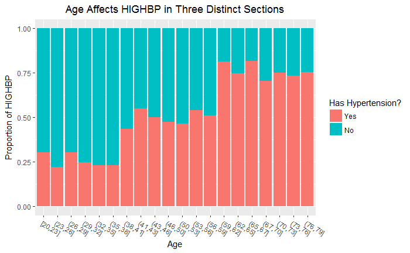

```r
ggplot(study_data, aes(cut_number(CLC_AGE, 20), fill = factor(HIGHBP))) +
  geom_bar(position = position_fill(reverse = TRUE)) +
  xlab("Age") +
  ylab("Proportion of HIGHBP") +
  ggtitle("Age Affects HIGHBP in Three Distinct Sections") +
  scale_fill_discrete(name = "Has Hypertension?", labels = c("Yes", "No")) +
  theme(plot.title = element_text(hjust = 0.5), axis.text.x = element_text(angle = -30, hjust = 0, vjust = 1))
```

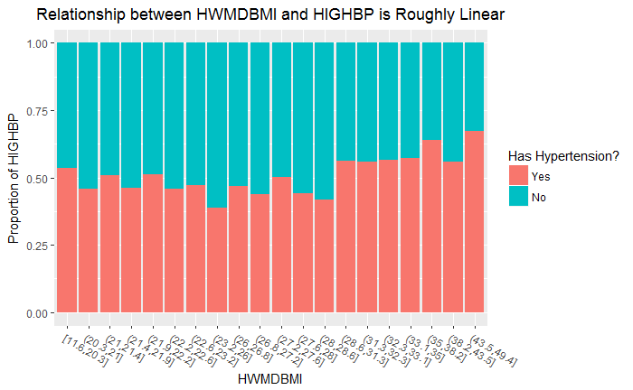

```r
ggplot(study_data, aes(cut_number(HWMDBMI, 20), fill = factor(HIGHBP))) +
  geom_bar(position = position_fill(reverse = TRUE)) +
  xlab("HWMDBMI") +
  ylab("Proportion of HIGHBP") +
  ggtitle("Relationship between HWMDBMI and HIGHBP is Roughly Linear") +
  scale_fill_discrete(name = "Has Hypertension?", labels = c("Yes", "No")) +
  theme(plot.title = element_text(hjust = 0.5), axis.text.x = element_text(angle = -30, hjust = 0, vjust = 1))
```

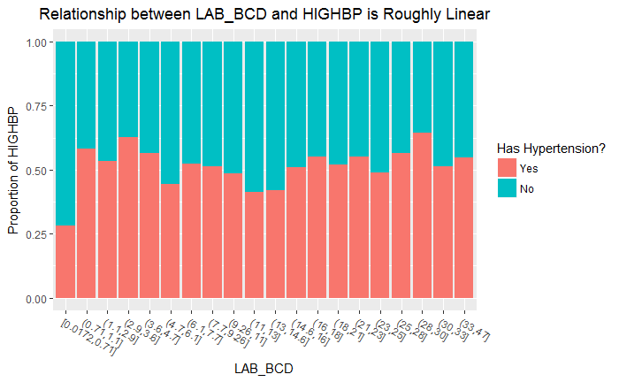

```r
ggplot(study_data, aes(cut_number(LAB_BCD, 20), fill = factor(HIGHBP))) +
  geom_bar(position = position_fill(reverse = TRUE)) +
  xlab("LAB_BCD") +
  ylab("Proportion of HIGHBP") +
  ggtitle("Relationship between LAB_BCD and HIGHBP is Roughly Linear") +
  scale_fill_discrete(name = "Has Hypertension?", labels = c("Yes", "No")) +
  theme(plot.title = element_text(hjust = 0.5), axis.text.x = element_text(angle = -30, hjust = 0, vjust = 1))
```

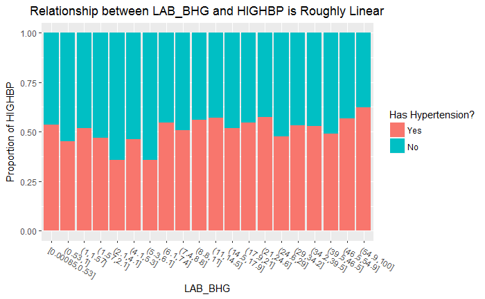

```r
ggplot(study_data, aes(cut_number(LAB_BHG, 20), fill = factor(HIGHBP))) +
  geom_bar(position = position_fill(reverse = TRUE)) +
  xlab("LAB_BHG") +
  ylab("Proportion of HIGHBP") +
  ggtitle("Relationship between LAB_BHG and HIGHBP is Roughly Linear") +
  scale_fill_discrete(name = "Has Hypertension?", labels = c("Yes", "No")) +
  theme(plot.title = element_text(hjust = 0.5), axis.text.x = element_text(angle = -30, hjust = 0, vjust = 1))
```

The relationship between Age and HIGHBP looks like a step function. Thus, a categorical version of CLC_AGE with three levels (called CLC_AGE_CAT) was added to the data frame. We later test whether replacing CLC_AGE with CLC_AGE_CAT in the model improves the model fit.

No higher-order terms were added to the model.

```r
# Make CLC_AGE into a categorical variable with three levels, and add this to our data frame
study_data = mutate(study_data, CLC_AGE_CAT = as.factor(cut_width(study_data$CLC_AGE, 20, boundary = 20, closed = "left")))
```

Since HIGHBP is a categorical variable that takes on only two values, it was modelled as a Bernoulli random variable. Three models were built, each using a different link function.

```r
# Uses log odds link function
model_logit = glm(as.factor(HIGHBP) ~ SMK_12+CLC_SEX+CLC_AGE_CAT+HWMDBMI+LAB_BCD+LAB_BHG, binomial(link = 'logit'), study_data)
# Uses inverse CDF of standard Normal distribution link function
model_probit = glm(as.factor(HIGHBP) ~ SMK_12+CLC_SEX+CLC_AGE_CAT+HWMDBMI+LAB_BCD+LAB_BHG, binomial(link = 'probit'), study_data)
# Uses complimentary log-log link function
model_cloglog = glm(as.factor(HIGHBP) ~ SMK_12+CLC_SEX+CLC_AGE_CAT+HWMDBMI+LAB_BCD+LAB_BHG, binomial(link = 'cloglog'), study_data)
```

To check how well these models fit the sample data, the Deviance or the Chi-Squared statistic would normally be used. However, our model includes continuous explanatory variables, which means that these statistics will not follow their theoretical asymptotic distributions. To get around this, the Hosmer-Lemeshow statistic was used instead, as suggested by our class textbook (page 136).

Unfortunately, the Hosmer-Lemeshow statistic is sensitive to the number of groups the data is split into, and there is no theoretical guidance for choosing this number. Thus, we calculated this statistic repeatedly by letting the number of groups vary between 10 and 60, and then graphed the results in the hopes that this would provide a more accurate assessment of fit.

The reader may wonder how the range of groups [10, 60] was chosen. The lower limit of 10 is simply the value commonly used with the Hosmer-Lemeshow test, as we could find no guidance for choosing a minimum number of groups.

We arrived at the upper limit of 60 using the following reasoning: For each of these three models, all the estimated probabilities of not having hypertension are between 10% and 90% (this is shown in the code below). Evenly splitting the 3060 observations in the data set into 60 groups leads to groups that each contain about 50 observations. Even with as many as 60 groups then, all the groups expect to have at least 5 people without hypertension and at least 5 people with hypertension. Thus, the Hosmer-Lemeshow statistic should still approximate a chi-square distribution with as many as 60 groups.

```r
# See that the minimum estimated probabilities that HIGHBP=2 are all greater than 10%
min(fitted.values(model_logit))
```

```
[1] 0.1210539
```

```r
min(fitted.values(model_probit))
```

```
[1] 0.1147758
```

```r
min(fitted.values(model_cloglog))
```

```
[1] 0.1427351
```

```r
# The minimum estimated probabilities that HIGHBP=1 are also greater than 10%
max(fitted.values(model_logit))
```

```
[1] 0.8671296
```

```r
max(fitted.values(model_probit))
```

```
[1] 0.8722835
```

```r
max(fitted.values(model_cloglog))
```

```
[1] 0.8935797
```

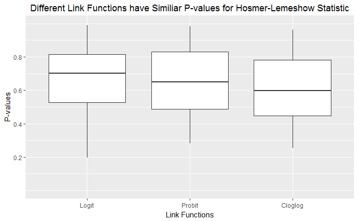

```r
# Calculate the Hosmer-Lemeshow statistic multiple times for each of the three models
pvalues_logit = sapply(X = seq(10, 60, 1), FUN = hoslem.test, x = model_logit$y, y = fitted.values(model_logit))["p.value",]
pvalues_probit = sapply(X = seq(10, 60, 1), FUN = hoslem.test, x = model_probit$y, y = fitted.values(model_probit))["p.value",]
pvalues_cloglog = sapply(X = seq(10, 60, 1), FUN = hoslem.test, x = model_cloglog$y, y = fitted.values(model_cloglog))["p.value",]
pvalues_logit = unlist(pvalues_logit)
pvalues_probit = unlist(pvalues_probit)
pvalues_cloglog = unlist(pvalues_cloglog)
# Plot distribution of Hosmer-Lemeshow statistics
ggplot(mapping = aes(x = factor(rep(c("Logit", "Probit", "Cloglog"),  each = 51), levels = c("Logit", "Probit", "Cloglog")),  y = c(pvalues_logit, pvalues_probit, pvalues_cloglog))) +
  geom_boxplot() +
  xlab("Link Functions") +
  scale_y_continuous("P-values", c(0.2, 0.4, 0.6, 0.8), limits = c(0, 1)) +
  ggtitle("Different Link Functions have Similiar P-values for Hosmer-Lemeshow Statistic") +
  theme(plot.title = element_text(hjust = 0.5))
```

We have been including CLC_AGE_CAT instead of CLC_AGE in the model so far, but does this really produce a model with better fit?

```r
# Look at two models, one with CLC_AGE and one with CLC_AGE_CAT, and compare their AIC.
summary(model_logit)
```

```
Call:
glm(formula = as.factor(HIGHBP) ~ SMK_12 + CLC_SEX + CLC_AGE_CAT +
    HWMDBMI + LAB_BCD + LAB_BHG, family = binomial(link = "logit"),
    data = study_data)

Deviance Residuals:
    Min       1Q   Median       3Q      Max
-1.9493  -0.9386  -0.5985   0.9306   2.0041

Coefficients:
                    Estimate Std. Error z value Pr(>|z|)
(Intercept)         1.524688   0.240480   6.340 2.29e-10 ***
SMK_122             0.423744   0.222665   1.903  0.05703 .
SMK_123            -0.020365   0.116046  -0.175  0.86069
CLC_SEX             0.249731   0.080104   3.118  0.00182 **
CLC_AGE_CAT[40,60) -1.058618   0.096901 -10.925  < 2e-16 ***
CLC_AGE_CAT[60,80] -2.179509   0.102949 -21.171  < 2e-16 ***
HWMDBMI            -0.025597   0.005741  -4.459 8.25e-06 ***
LAB_BCD            -0.003313   0.003742  -0.885  0.37598
LAB_BHG            -0.004878   0.002179  -2.238  0.02520 *
---
Signif. codes:  0 *** 0.001 ** 0.01 * 0.05 . 0.1   1

(Dispersion parameter for binomial family taken to be 1)

    Null deviance: 4240.9  on 3059  degrees of freedom
Residual deviance: 3662.7  on 3051  degrees of freedom
AIC: 3680.7

Number of Fisher Scoring iterations: 4
```

```r
summary(update(model_logit, ~ . -CLC_AGE_CAT+CLC_AGE))
```

```
Call:
glm(formula = as.factor(HIGHBP) ~ SMK_12 + CLC_SEX + HWMDBMI +
    LAB_BCD + LAB_BHG + CLC_AGE, family = binomial(link = "logit"),
    data = study_data)

Deviance Residuals:
    Min       1Q   Median       3Q      Max
-1.9795  -0.9791  -0.5898   0.9912   2.0621

Coefficients:
             Estimate Std. Error z value Pr(>|z|)
(Intercept)  2.839367   0.258248  10.995  < 2e-16 ***
SMK_122      0.375068   0.219892   1.706  0.08807 .
SMK_123     -0.020544   0.114553  -0.179  0.85767
CLC_SEX      0.254117   0.078897   3.221  0.00128 **
HWMDBMI     -0.026528   0.005663  -4.684 2.81e-06 ***
LAB_BCD     -0.004011   0.003676  -1.091  0.27525
LAB_BHG     -0.004894   0.002151  -2.275  0.02292 *
CLC_AGE     -0.047805   0.002453 -19.490  < 2e-16 ***
---
Signif. codes:  0 *** 0.001 ** 0.01 * 0.05 . 0.1   1

(Dispersion parameter for binomial family taken to be 1)

    Null deviance: 4240.9  on 3059  degrees of freedom
Residual deviance: 3744.2  on 3052  degrees of freedom
AIC: 3760.2

Number of Fisher Scoring iterations: 4
```

Even with the extra parameter, the model with CLC_AGE_CAT has a smaller AIC value than the model with CLC_AGE. so we left CLC_AGE_CAT in the model.

We now checked for multicollinearity between the explanatory variables.

```r
# Calculate the Generalized Variance Inflation Factors (GVIF) for each predictor
vif(model_logit)
```

```
                GVIF Df GVIF^(1/(2*Df))
SMK_12      1.006989  2        1.001743
CLC_SEX     1.006973  1        1.003480
CLC_AGE_CAT 1.017195  2        1.004271
HWMDBMI     1.001815  1        1.000907
LAB_BCD     1.015029  1        1.007486
LAB_BHG     1.001066  1        1.000533
```

All of these values are close to 1, so we concluded that there was essentially no multicollinearity between the variables in our model.

It is often recommended that residual plots be examined to check for possible problems in the model.

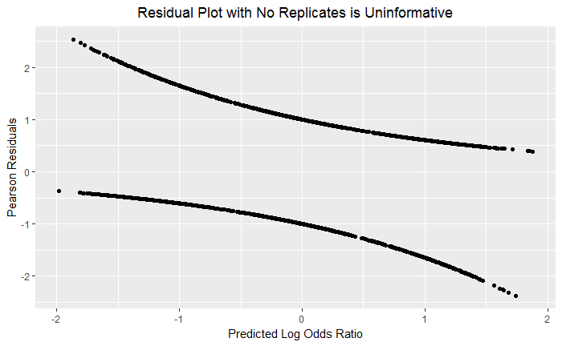

```r
# Build residual plot
ggplot(mapping = aes(model_logit$linear.predictors, residuals(model_logit, "pearson"))) +
  geom_point() +
  xlab("Predicted Log Odds Ratio") + ylab("Pearson Residuals") +
  ggtitle("Residual Plot with No Replicates is Uninformative") +
  theme(plot.title = element_text(hjust = 0.5))
```

This residual plot does not seem very imformative however, perhaps because the number of unique covariate patterns in our data set equals the number of observations.

Having done what we felt was a satisfactory job of checking the model fit, we accepted our model as being a reasonable approximation of reality.

### Drawing Conclusions

To determine which variables have an effect on the response HIGHBP, we removed each variable in turn and compared the difference in deviance statistics. Even with sparse data such as ours, this difference in deviance should still approximate a chi-square distribution since the degree of freedom is small.

```r
drop1(model_logit, test = "LRT")
```

```
Single term deletions

Model:
as.factor(HIGHBP) ~ SMK_12 + CLC_SEX + CLC_AGE_CAT + HWMDBMI +
    LAB_BCD + LAB_BHG
            Df Deviance    AIC    LRT  Pr(>Chi)
<none>           3662.7 3680.7
SMK_12       2   3667.7 3681.7   4.96   0.08392 .
CLC_SEX      1   3672.5 3688.5   9.74   0.00180 **
CLC_AGE_CAT  2   4178.7 4192.7 516.00 < 2.2e-16 ***
HWMDBMI      1   3682.9 3698.9  20.14 7.207e-06 ***
LAB_BCD      1   3663.5 3679.5   0.78   0.37592
LAB_BHG      1   3667.7 3683.7   5.02   0.02500 *
---
Signif. codes:  0 *** 0.001 ** 0.01 * 0.05 . 0.1   1
```

Even when taking into account the other variables in the model, there is strong evidence that sex, age, and body mass index influence average hypertension, and weaker evidence that blood mercury levels (LAB_BHG) and smoking status have an effect. It is inconclusive whether blood cadmium levels (LAB_BCD) affect average hypertension.

We now attempt to answer whether different genders experience difference risk factors for HIGHBP.

```r
# Test whether the interaction terms between CLC_SEX and other variables are non-zero
model_gender = update(model_logit, ~ . + CLC_SEX:SMK_12 + CLC_SEX:CLC_AGE_CAT + CLC_SEX:HWMDBMI + CLC_SEX:LAB_BCD + CLC_SEX:LAB_BHG)
drop1(model_gender, test = "LRT")
```

```
Single term deletions

Model:
as.factor(HIGHBP) ~ SMK_12 + CLC_SEX + CLC_AGE_CAT + HWMDBMI +
    LAB_BCD + LAB_BHG + SMK_12:CLC_SEX + CLC_SEX:CLC_AGE_CAT +
    CLC_SEX:HWMDBMI + CLC_SEX:LAB_BCD + CLC_SEX:LAB_BHG
                    Df Deviance    AIC    LRT Pr(>Chi)
<none>                   3656.2 3688.2
SMK_12:CLC_SEX       2   3657.2 3685.2 1.0624  0.58789
CLC_SEX:CLC_AGE_CAT  2   3657.1 3685.1 0.9733  0.61469
CLC_SEX:HWMDBMI      1   3659.7 3689.7 3.4932  0.06162 .
CLC_SEX:LAB_BCD      1   3656.7 3686.7 0.5509  0.45793
CLC_SEX:LAB_BHG      1   3656.4 3686.4 0.2108  0.64612
---
Signif. codes:  0 *** 0.001 ** 0.01 * 0.05 . 0.1   1
```

There is some weak evidence that the effect of body mass index on average hypertension does differ between genders, but little evidence that the effect of other variables differ by gender.

Do people of different ages experience different risk factors for HIGHBP?

```r
# Test whether the interaction terms between CLC_AGE_CAT and other variables are non-zero
model_age = update(model_logit, ~ . + CLC_AGE_CAT:SMK_12 + CLC_AGE_CAT:CLC_SEX + CLC_AGE_CAT:HWMDBMI + CLC_AGE_CAT:LAB_BCD + CLC_AGE_CAT:LAB_BHG)
drop1(model_age, test = "LRT")
```

```
Single term deletions

Model:
as.factor(HIGHBP) ~ SMK_12 + CLC_SEX + CLC_AGE_CAT + HWMDBMI +
    LAB_BCD + LAB_BHG + SMK_12:CLC_AGE_CAT + CLC_SEX:CLC_AGE_CAT +
    CLC_AGE_CAT:HWMDBMI + CLC_AGE_CAT:LAB_BCD + CLC_AGE_CAT:LAB_BHG
                    Df Deviance    AIC    LRT Pr(>Chi)
<none>                   3649.9 3691.9
SMK_12:CLC_AGE_CAT   4   3656.6 3690.6 6.7432   0.1501
CLC_SEX:CLC_AGE_CAT  2   3651.1 3689.1 1.1810   0.5540
CLC_AGE_CAT:HWMDBMI  2   3651.9 3689.9 2.0749   0.3544
CLC_AGE_CAT:LAB_BCD  2   3651.6 3689.6 1.6810   0.4315
CLC_AGE_CAT:LAB_BHG  2   3650.8 3688.8 0.9061   0.6357
```

There is little evidence here to suggest that the risk factors of hypertension differ on average between age groups.

These conclusions should be tempered however because of the following flaws in our methodology:

- The uncertainty in the estimated censored and missing data was ignored. Given that a quarter of the observations contained at least one of these types of data, it is easy to imagine how ignoring this uncertainty led to artificially decisive conclusions. For the competition, a method such as bootstrapping could be used to estimate the variance of these estimates.
- We used jittering to estimate the censored data, but this method should be improved upon since almost 20% of observations contain censored data.

### References

Breiman, L., & Spector, P. (1992). Submodel Selection and Evaluation in Regression. The X-Random Case. International Statistical Review / Revue Internationale De Statistique, 60(3), 291. doi:10.2307/1403680

Lafleur, B., Lee, W., Billhiemer, D., Lockhart, C., Liu, J., & Merchant, N. (2011). Statistical methods for assays with limits of detection: Serum bile acid as a differentiator between patients with normal colons, adenomas, and colorectal cancer. Journal of Carcinogenesis, 10(1), 12. doi:10.4103/1477-3163.79681